# Fauna observaties

De aanwezigheid van vogels en andere fauna in de buurt wijst niet alleen op een gezonde leefomgeving, maar brengt een wijk ook tot leven. Groen en fauna gaan hand in hand; hieronder laten we zien dat meer groen in een wijk meer dieren aantrekt.

Voor waarnemingen gebruiken we het aantal dier waarnemingen per wijk in een jaar, verzameld door de website https://gbif.org*.

Hieronder plotten we 5 wijken uit breda die de meeste fauna observaties hebben. Daarbij kijken we ook naar de variabele "evi" (de planten index), zodat per wijk duidelijk wordt wat de relatie is tussen hoe groen de wijk is, en hoe veel fauna observaties er zijn

* De hele dataset is te downloaden op https://doi.org/10.15468/dl.ub8wrd

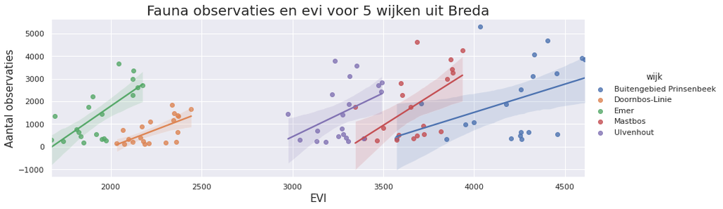

## Dieper in de data

Een regressie model toont de relaties tussen fauna observaties aan een kant, en jaar, wijk en evi aan de andere kant. Zoals hieronder is te zien groeit het relatieve aantal observaties hard over de laatste 20 jaar - te verklaren door het populairder worden van het registreren van waarnemingen. Ook verschillen de aantal waarnemingen per wijk, de ene wijk is aantrekkelijker voor dieren dan de andere. Per wijk zal er ook verschil ziten in het aantal mensen wat waarnemingen registreert.

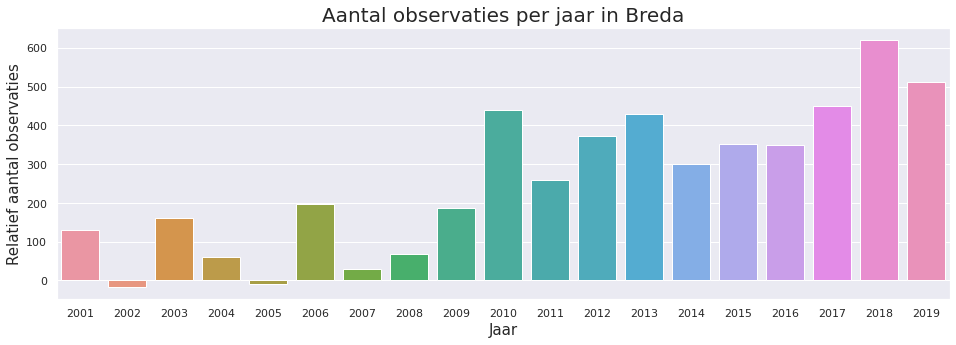

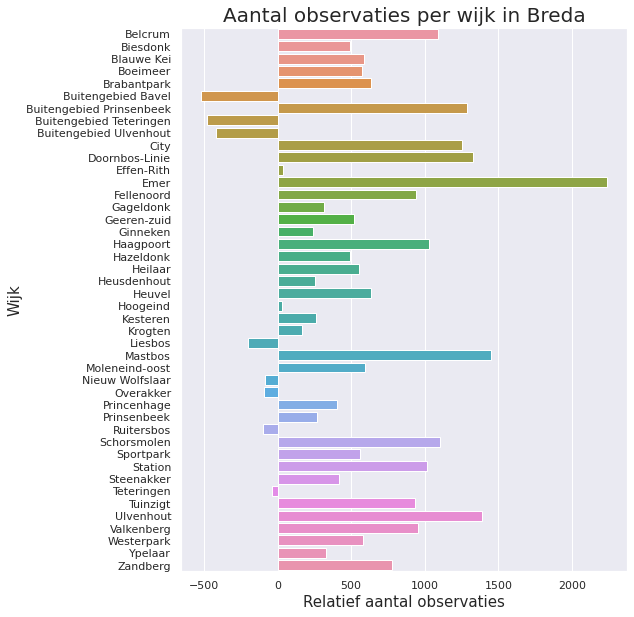

## EVI

OLS Regression Results

| Dep. Variable: | obs | R-squared: | 0.646 |
| --- | --- | --- | --- |
| Model: | OLS | Adj. R-squared: | 0.611 |
| Method: | Least Squares | F-statistic: | 18.70 |
| Date: | Sun, 01 Nov 2020 | Prob (F-statistic): | 8.92e-110 |
| Time: | 15:50:05 | Log-Likelihood: | -5392.2 |
| No. Observations: | 721 | AIC: | 1.091e+04 |
| Df Residuals: | 656 | BIC: | 1.121e+04 |
| Df Model: | 64 |  |  |
| Covariance Type: | nonrobust |  |  |

|  | coef | std err | t | P>\|t\| | [0.025 | 0.975] |
| --- | --- | --- | --- | --- | --- | --- |
| Intercept | -2370.9633 | 574.909 | -4.124 | 0.000 | -3499.846 | -1242.080 |
| C(wijk)[T.Belcrum] | 1089.5262 | 306.044 | 3.560 | 0.000 | 488.583 | 1690.469 |
| C(wijk)[T.Biesdonk] | 490.8588 | 323.425 | 1.518 | 0.130 | -144.215 | 1125.932 |
| C(wijk)[T.Blauwe Kei] | 583.9280 | 220.019 | 2.654 | 0.008 | 151.901 | 1015.955 |
| C(wijk)[T.Boeimeer] | 574.1069 | 196.058 | 2.928 | 0.004 | 189.130 | 959.083 |
| C(wijk)[T.Brabantpark] | 631.6813 | 203.180 | 3.109 | 0.002 | 232.720 | 1030.643 |
| C(wijk)[T.Buitengebied Bavel] | -520.4214 | 227.378 | -2.289 | 0.022 | -966.898 | -73.944 |
| C(wijk)[T.Buitengebied Prinsenbeek] | 1288.6876 | 253.293 | 5.088 | 0.000 | 791.324 | 1786.051 |
| C(wijk)[T.Buitengebied Teteringen] | -482.4349 | 203.226 | -2.374 | 0.018 | -881.488 | -83.382 |
| C(wijk)[T.Buitengebied Ulvenhout] | -417.4648 | 220.031 | -1.897 | 0.058 | -849.514 | 14.584 |
| C(wijk)[T.City] | 1254.0938 | 343.202 | 3.654 | 0.000 | 580.186 | 1928.001 |
| C(wijk)[T.Doornbos-Linie] | 1325.0840 | 208.092 | 6.368 | 0.000 | 916.478 | 1733.690 |
| C(wijk)[T.Effen-Rith] | 36.1648 | 214.718 | 0.168 | 0.866 | -385.453 | 457.783 |
| C(wijk)[T.Emer] | 2237.3168 | 248.212 | 9.014 | 0.000 | 1749.930 | 2724.704 |
| C(wijk)[T.Fellenoord] | 939.2124 | 312.281 | 3.008 | 0.003 | 326.021 | 1552.404 |
| C(wijk)[T.Gageldonk] | 314.5072 | 174.429 | 1.803 | 0.072 | -27.999 | 657.014 |
| C(wijk)[T.Geeren-zuid] | 516.2657 | 237.988 | 2.169 | 0.030 | 48.955 | 983.576 |
| C(wijk)[T.Ginneken] | 239.7228 | 154.694 | 1.550 | 0.122 | -64.032 | 543.477 |
| C(wijk)[T.Haagpoort] | 1030.0355 | 297.978 | 3.457 | 0.001 | 444.931 | 1615.140 |
| C(wijk)[T.Hazeldonk] | 490.0736 | 152.359 | 3.217 | 0.001 | 190.904 | 789.243 |
| C(wijk)[T.Heilaar] | 550.0322 | 203.218 | 2.707 | 0.007 | 150.997 | 949.068 |
| C(wijk)[T.Heusdenhout] | 251.8115 | 158.450 | 1.589 | 0.112 | -59.319 | 562.942 |
| C(wijk)[T.Heuvel] | 632.4075 | 207.147 | 3.053 | 0.002 | 225.656 | 1039.159 |
| C(wijk)[T.Hoogeind] | 29.5873 | 152.743 | 0.194 | 0.846 | -270.336 | 329.511 |
| C(wijk)[T.Kesteren] | 259.9754 | 355.844 | 0.731 | 0.465 | -438.755 | 958.705 |
| C(wijk)[T.Krogten] | 168.9785 | 294.753 | 0.573 | 0.567 | -409.794 | 747.751 |
| C(wijk)[T.Liesbos] | -203.9548 | 175.648 | -1.161 | 0.246 | -548.854 | 140.945 |
| C(wijk)[T.Mastbos] | 1448.2517 | 186.828 | 7.752 | 0.000 | 1081.399 | 1815.104 |
| C(wijk)[T.Moleneind-oost] | 595.5163 | 233.990 | 2.545 | 0.011 | 136.057 | 1054.976 |
| C(wijk)[T.Nieuw Wolfslaar] | -87.1154 | 156.653 | -0.556 | 0.578 | -394.717 | 220.487 |
| C(wijk)[T.Overakker] | -94.4540 | 156.625 | -0.603 | 0.547 | -402.001 | 213.093 |
| C(wijk)[T.Princenhage] | 403.8453 | 169.500 | 2.383 | 0.017 | 71.017 | 736.674 |
| C(wijk)[T.Prinsenbeek] | 270.4604 | 169.106 | 1.599 | 0.110 | -61.594 | 602.514 |
| C(wijk)[T.Ruitersbos] | -100.6396 | 158.449 | -0.635 | 0.526 | -411.767 | 210.488 |
| C(wijk)[T.Schorsmolen] | 1102.4523 | 381.197 | 2.892 | 0.004 | 353.940 | 1850.965 |
| C(wijk)[T.Sportpark] | 558.3904 | 209.932 | 2.660 | 0.008 | 146.170 | 970.611 |
| C(wijk)[T.Station] | 1016.4393 | 325.280 | 3.125 | 0.002 | 377.723 | 1655.155 |
| C(wijk)[T.Steenakker] | 416.8090 | 245.915 | 1.695 | 0.091 | -66.067 | 899.685 |
| C(wijk)[T.Teteringen] | -39.7752 | 164.733 | -0.241 | 0.809 | -363.244 | 283.693 |
| C(wijk)[T.Tuinzigt] | 930.9629 | 291.423 | 3.195 | 0.001 | 358.729 | 1503.197 |
| C(wijk)[T.Ulvenhout] | 1391.3935 | 155.938 | 8.923 | 0.000 | 1085.197 | 1697.590 |
| C(wijk)[T.Valkenberg] | 955.5194 | 292.131 | 3.271 | 0.001 | 381.895 | 1529.144 |
| C(wijk)[T.Westerpark] | 579.3065 | 201.708 | 2.872 | 0.004 | 183.236 | 975.378 |
| C(wijk)[T.Ypelaar] | 330.1719 | 174.146 | 1.896 | 0.058 | -11.778 | 672.122 |
| C(wijk)[T.Zandberg] | 775.2221 | 259.008 | 2.993 | 0.003 | 266.638 | 1283.806 |
| C(year)[T.2001] | 129.3374 | 112.978 | 1.145 | 0.253 | -92.506 | 351.180 |
| C(year)[T.2002] | -16.9505 | 108.234 | -0.157 | 0.876 | -229.477 | 195.575 |
| C(year)[T.2003] | 161.2825 | 131.352 | 1.228 | 0.220 | -96.638 | 419.203 |
| C(year)[T.2004] | 60.3754 | 115.879 | 0.521 | 0.603 | -167.164 | 287.915 |
| C(year)[T.2005] | -9.4070 | 115.690 | -0.081 | 0.935 | -236.575 | 217.761 |
| C(year)[T.2006] | 196.8399 | 120.849 | 1.629 | 0.104 | -40.457 | 434.137 |
| C(year)[T.2007] | 29.2544 | 103.939 | 0.281 | 0.778 | -174.840 | 233.349 |
| C(year)[T.2008] | 69.0179 | 103.320 | 0.668 | 0.504 | -133.860 | 271.896 |
| C(year)[T.2009] | 185.4657 | 109.207 | 1.698 | 0.090 | -28.973 | 399.904 |
| C(year)[T.2010] | 440.2022 | 121.477 | 3.624 | 0.000 | 201.672 | 678.732 |
| C(year)[T.2011] | 259.3429 | 103.455 | 2.507 | 0.012 | 56.199 | 462.487 |
| C(year)[T.2012] | 371.7262 | 105.291 | 3.530 | 0.000 | 164.979 | 578.474 |
| C(year)[T.2013] | 428.6055 | 106.281 | 4.033 | 0.000 | 219.914 | 637.297 |
| C(year)[T.2014] | 300.7658 | 101.577 | 2.961 | 0.003 | 101.311 | 500.220 |
| C(year)[T.2015] | 351.9534 | 102.401 | 3.437 | 0.001 | 150.880 | 553.027 |
| C(year)[T.2016] | 348.7704 | 101.780 | 3.427 | 0.001 | 148.917 | 548.624 |
| C(year)[T.2017] | 450.6370 | 100.708 | 4.475 | 0.000 | 252.889 | 648.385 |
| C(year)[T.2018] | 620.4807 | 101.620 | 6.106 | 0.000 | 420.940 | 820.021 |
| C(year)[T.2019] | 510.5726 | 102.071 | 5.002 | 0.000 | 310.148 | 710.997 |
| evi | 0.6786 | 0.177 | 3.838 | 0.000 | 0.331 | 1.026 |

| Omnibus: | 261.190 | Durbin-Watson: | 2.218 |
| --- | --- | --- | --- |
| Prob(Omnibus): | 0.000 | Jarque-Bera (JB): | 2928.479 |
| Skew: | 1.294 | Prob(JB): | 0.00 |
| Kurtosis: | 12.528 | Cond. No. | 2.17e+05 |

Warnings:  
[1] Standard Errors assume that the covariance matrix of the errors is correctly specified.  
[2] The condition number is large, 2.17e+05. This might indicate that there are  
strong multicollinearity or other numerical problems.